# Running the linear model on breast cancer study

Tara Eicher and Jalal K. Siddiqui, PhD

1/11/2022

## Introduction

A previous study had conducted both gene expression and metabolomics profiling of tissue samples from breast cancer patients (1). This vigenette will highlight the analysis we conduct on the breast cancer data.

## Loading in IntLIM and Files

IntLIM, available from Github, can be installed as in the documentation. Once IntLIM is installed, what is necessary is loading in the library. First clear the workspace.

```r
rm(list = ls())
if(!require("devtools")){
  install.packages("devtools")
}
library("devtools")
install_github("ncats/IntLIM")
```

```
## Skipping install of 'IntLIM' from a github remote, the SHA1 (cbed4fd7) has not changed since last install.
##   Use `force = TRUE` to force installation
```

```r
library(IntLIM)
```

For breast cancer study, both gene expression (available on Gene Expression Omnibus Accession Number: GSE37751) and metabolomics(1) (http://www.jci.org/articles/view/71180/sd/2) data are available online. Much of this data had been processed as previously described (1). Probes from the Affymetrix data not mapping to a gene symbol were removed. Additionally, only the probe corresponding to the highest mean expression was used for analysis when multiple probes corresponded to a single gene. This resulted in a total of 20,254 genes for 108 patient samples. The Metabolon data did not need to be filtered by coefficient of variation, as there were no technical replicates. The resulting data consisted of 536 metabolites with 132 patient samples.

This data has been formatted for IntLIM. We load in the data as follows. The function **ShowStats()** will give a summary of the data. We find that we have gene expression data involving 20,254 genes and 536 metabolites with 108 patient samples.

```r
csvfile <- file.path(getwd(), "/BRCA_data/input.csv")
inputData <- IntLIM::ReadData(inputFile = csvfile,analyteType1id='id',analyteType2id='id',
                              class.feat = list(DIAG = "factor",
                                                RACE.ETHNICITY = "factor",
                                                AGE = "numeric"))
```

```
## IntLIMData created
```

```r
IntLIM::ShowStats(inputData)
```

```
##   Num_Analytes_Type1 Num_Analytes_Type2 Num_Samples
## 1              20254                536         108
```

## Filtering Gene Expression and Metabolite Data

The **FilterData()** function is used to filter the data. We remove genes with mean below the 10th percentile. Furthermore, we remove analytes with more than 80% missing values. This results in gene expression data involving 18,228 genes, 536 metabolites, and 108 patient samples.

```r
inputDatafilt <- IntLIM::FilterData(inputData,analyteType1perc=0.10, analyteMiss = 0.80)
IntLIM::ShowStats(inputDatafilt)
```

```
##   Num_Analytes_Type1 Num_Analytes_Type2 Num_Samples
## 1              18228                536         108
```

We can obtain boxplot distributions of the data as follows. This is used to make figures.

```r
IntLIM::PlotDistributions(inputDatafilt)
```

[interactive chart not shown]

## Principal Component Analysis

The principal component analysis is performed on filtered metabolite and gene expression data to obtain visual representations showing how different sub-sections of the data could be grouped into different clusters. Common samples patient samples (either tumor or adjacent non-tumor samples). Blue samples indicate tumor samples and red samples indicate non-tumor samples. Note the clear delineation of samples.

```r
IntLIM::PlotPCA(inputDatafilt, stype = "DIAG")
```

[interactive chart not shown]

## Running Linear Model

The linear model is for integrating multi-omics data is: a_i = β0 + β1 a_j + β2 p + β3 (a_j:p) + Σ(β(3+c) C) + ε where ‘a_i’ and ‘a_j’ are (optionally log-transformed) analyte abundances, ‘p’ is phenotype (cancer type, patient diagnosis, treatment group, etc), ‘(a_j:p)’ is the association between analyte level and phenotype, C is a set of clinical covariates (e.g. age, sex, etc), c is a covariate index, and ‘ε’ is the error term that is normally distributed. A statistically significant p-value of the ‘(a_j:p)’ association term indicates that the slope relating analyte levels is different from one phenotype compared to another. We run a linear model on tumor (n = 61) and non-tumor samples (n = 47) that included 18,228 genes and 536 metabolites (total of 9,770,208 possible associations and hence models). The model is run as below by calling **RunIntLim()**. **DistPvalues()** allows us to obtain a distribution of p-values for the (a_j:p) term, and **DistRSquared()** allows us to obtain a distribution of R^2 values for the models. **InteractionCoefficientGraph()** allows us to obtain an ordered plot of the (a_j:p) term coefficients. We also show a volcano plot showing the relationship between interaction coefficients and unadjusted p-values using **pvalCoefVolcano()**.

Covariates (e.g. age and batch) may also be included in the models as a list using the **covar** parameter. Please be advised that not all covariates in the experiment need be included. In particular, colliders (variables influenced by one or more other variables) should not be included, and potential confounding variables should be included. The choice of covariates should be determined by the experiment.

Note that the user must select either analyte type 1 or analyte type 2 for the independent and outcome variables. This choice should be biologically motivated. For instance, if the user wants to investigate metabolite abundances that are influenced by gene expression level and metabolite abundance is analyte type 1 and gene expression is analyte type 2, then the outcome would be analyte type 1 and the independent variable would be analyte type 2.

```r
myres <- IntLIM::RunIntLim(inputDatafilt, stype="DIAG", covar = c("AGE", "RACE.ETHNICITY"), outcome = 2, independent.var.type = 1, suppressWarnings = TRUE,
                           save.covar.pvals = TRUE)
```

```
## Running the analysis on discrete data with group sizes 47 61
```

```
## 10 % complete
```

```
## 20 % complete
```

```
## 30 % complete
```

```
## 40 % complete
```

```
## 50 % complete
```

```
## 60 % complete
```

```
## 70 % complete
```

```
## 80 % complete
```

```
## 90 % complete
```

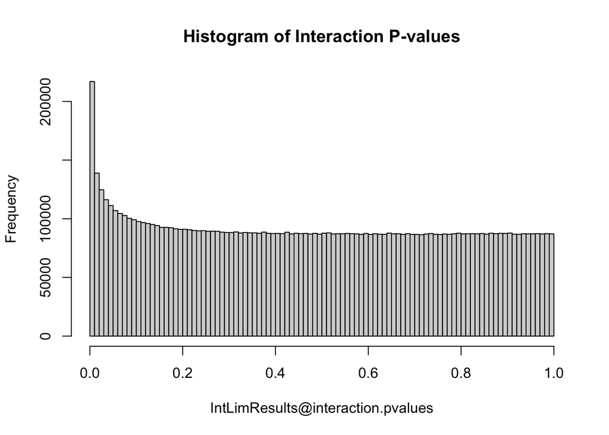

```r
IntLIM::DistPvalues(myres, adjusted = FALSE)
```

```r
IntLIM::pvalCoefVolcano(inputResults = myres, inputData = inputDatafilt,
                        pvalcutoff = 0.05)
```

```
## 9168683 pairs found given cutoffs
```

[figure not shown]

The next step is to process the results of this model by filtering the results of the linear model by FDR-adjusted p-value cutoff (0.10 selected here) for the (a_j:p) association coefficient. We further may only interested in results where the interaction coefficient is in the top Xth percentile (e.g. 50th shown here) and where the model fit as measured by R^2 value is above a given cutoff (e.g. 0.2). This is done with the **ProcessResults()** function.

It is also possible to filter for significant main effects (independent analyte level or phenotype). Users can then determine which significant pairs also have significant main effects.

```r
myres10 <- IntLIM::ProcessResults(myres,  inputDatafilt, pvalcutoff = 0.10,
                                  coeffPercentile = 0.5,
                                  rsquaredCutoff = 0.2)
```

```
## 14583 pairs found given cutoffs
```

```r
myres10.stype <- IntLIM::ProcessResults(myres,  inputDatafilt, pvalcutoff = 0.10,
                                  coeffPercentile = 0.5,
                                  rsquaredCutoff = 0.2, coefficient = "stype")
```

```
## 20065 pairs found given cutoffs
```

```r
myres10.a <- IntLIM::ProcessResults(myres,  inputDatafilt, pvalcutoff = 0.10,
                                  coeffPercentile = 0.5,
                                  rsquaredCutoff = 0.2, coefficient = "analyte")
```

```
## 14091 pairs found given cutoffs
```

```r
IntLIM::OutputResults(inputResults = myres10, filename = "bcresults10_race_age.csv")
```

```
## Wrote results to bcresults10_race_age.csv
```

We find that we obtain 14,583 pairs.

We can show some example plots of some of these pairs. The first example is the ASNS vs. glutamine.

```r
IntLIM::PlotPair(inputDatafilt, myres, independentAnalyteOfInterest = "ASNS",
                 outcomeAnalyteOfInterest = "glutamine",
                 independentVariable = 1,
                 outcome = 2)
```

[interactive chart not shown]

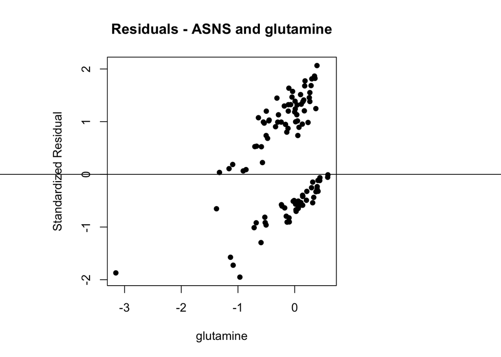

```r
IntLIM::PlotPairResiduals(inputDatafilt, myres, independentAnalyteOfInterest = "ASNS",
                 outcomeAnalyteOfInterest = "glutamine",
                 independentVariable = 1,
                 outcome = 2)
```

```r
IntLIM::PlotPair(inputDatafilt, myres, independentAnalyteOfInterest = "SLC7A1",
                 outcomeAnalyteOfInterest = "glutamine",
                 independentVariable = 1,
                 outcome = 2)
```

[interactive chart not shown]

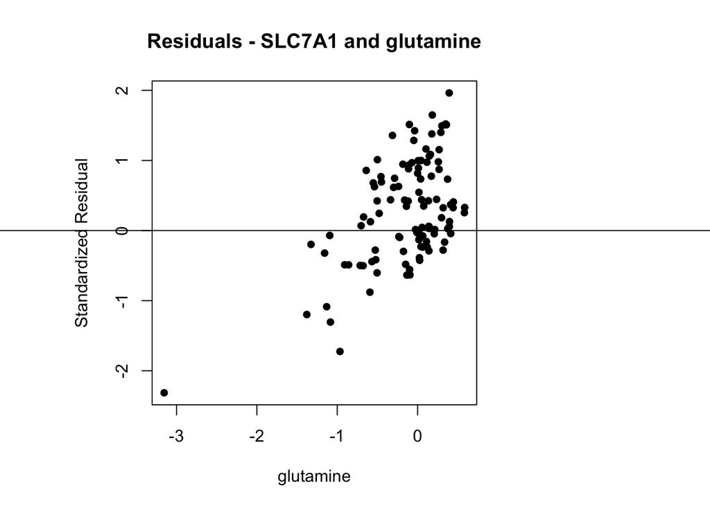

```r
IntLIM::PlotPairResiduals(inputDatafilt, myres, independentAnalyteOfInterest = "SLC7A1",
                 outcomeAnalyteOfInterest = "glutamine",
                 independentVariable = 1,
                 outcome = 2)
```

We also find that the pair 2-hydroxyglutarate and GPT2 is significant.  
However, the residuals increase as 2-hydroxyglutarate levels increase, indicating that the predictions are biased toward the average value.

```r
IntLIM::PlotPair(inputDatafilt, myres, independentAnalyteOfInterest = "GPT2",
                 outcomeAnalyteOfInterest = "2-hydroxyglutarate",
                 independentVariable = 1,
                 outcome = 2)
```

[interactive chart not shown]

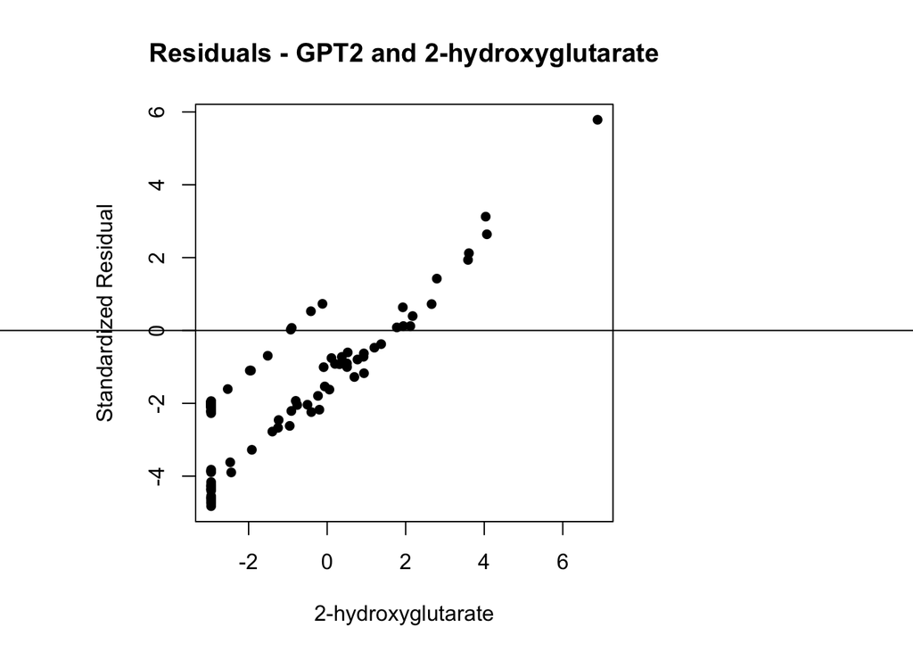

```r
IntLIM::PlotPairResiduals(inputDatafilt, myres, independentAnalyteOfInterest = "GPT2",
                 outcomeAnalyteOfInterest = "2-hydroxyglutarate",
                 independentVariable = 1,
                 outcome = 2)
```

```r
IntLIM::PlotPair(inputDatafilt, myres, independentAnalyteOfInterest = "MYC",
                 outcomeAnalyteOfInterest = "2-hydroxyglutarate",
                 independentVariable = 1,
                 outcome = 2)
```

[interactive chart not shown]

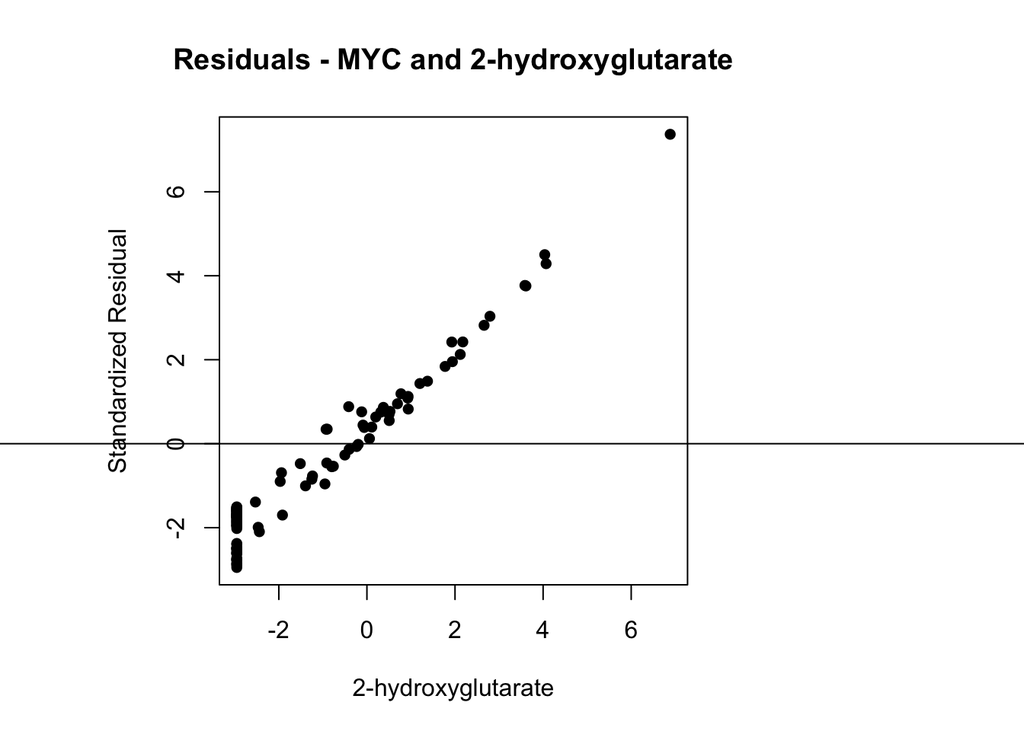

```r
IntLIM::PlotPairResiduals(inputDatafilt, myres, independentAnalyteOfInterest = "MYC",
                 outcomeAnalyteOfInterest = "2-hydroxyglutarate",
                 independentVariable = 1,
                 outcome = 2)
```

The list of unique genes and metabolites in these pairs can be used to conduct a pathway enrichment analysis. Using RaMP, we query the set of pairs for shared pathways and shared reactions. Before running these commands, it is assumed that you have installed the RaMP database locally. Instructions to install RaMP are here: https://github.com/ncats/RaMP-DB

```r
if(!require("RaMP")){
 install_github("ncats/RAMP-DB")
}
```

```r
library(RaMP)

# Load files.
fdata <- inputDatafilt@analyteType2MetaData

# Match metabolite ID's to source.
metabid <- lapply(myres10$Analyte2, function(analyte){
  return(paste(fdata[analyte, "IDtype"], fdata[analyte, "sourceID"], sep = ":"))
})

# Match gene ID's to source.
geneid <- paste0("gene_symbol:", myres10$Analyte1)

# Connect to RaMP. Replace with your MySQL password, or "" if not using a password.
password <- unlist(unname(read.csv(file.path("~/mysql_pw.txt"), header = FALSE)))
pkg.globals <- setConnectionToRaMP(dbname = "ramp", username = "root", conpass = password,
  host = "localhost")

# Find which pairs share pathways.
sharesPathway <- lapply(1:nrow(myres10), function(i){
  shares <- FALSE
  pwayResult <- getPathwayFromAnalyte(c(metabid[[i]], geneid[[i]]))
  pwayResultMetab <- pwayResult$pathwayId[which(pwayResult$inputId == metabid[[i]])]
  pwayResultGene <- pwayResult$pathwayId[which(pwayResult$inputId == geneid[[i]])]
  if(length(intersect(pwayResultMetab, pwayResultGene)) > 0){
    shares <- TRUE
  }
  return(shares)
})

# Find which pairs share reactions.
sharesRxn <- lapply(1:nrow(myres10), function(i){
  shares <- FALSE
  tryCatch({
    rxnResult <- rampFastCata(metabid[[i]])$rxn_partner_ids
    rxnResultAll <- unlist(lapply(rxnResult, function(res){
      return(strsplit(res, "; ")[[1]])
    }))
    if(geneid[[i]] %in% rxnResultAll){
      shares <- TRUE
    }
  }, error = function(cond){})
  return(shares)
})
```

## Cross-Validation

```r
folds <- 5
crossValResults <- IntLIM::RunCrossValidation(inputData = inputData, analyteType1perc = 0.10,
                   analyteMiss = 0.80, stype="DIAG", outcome = c(2),
                   independent.var.type = c(1), pvalcutoff = 0.10,
                   rsquaredCutoff = 0.2, suppressWarnings = TRUE,
                   folds = 5, interactionCoeffPercentile = 0.5,
                   covar = c("AGE", "RACE.ETHNICITY"))
```

```
## Running the analysis on discrete data with group sizes 37 49
```

```
## 10 % complete
```

```
## 20 % complete
```

```
## 30 % complete
```

```
## 40 % complete
```

```
## 50 % complete
```

```
## 60 % complete
```

```
## 70 % complete
```

```
## 80 % complete
```

```
## 90 % complete
```

```
## Running the analysis on discrete data with group sizes 37 49
```

```
## 10 % complete
```

```
## 20 % complete
```

```
## 30 % complete
```

```
## 40 % complete
```

```
## 50 % complete
```

```
## 60 % complete
```

```
## 70 % complete
```

```
## 80 % complete
```

```
## 90 % complete
```

```
## Running the analysis on discrete data with group sizes 41 45
```

```
## 10 % complete
```

```
## 20 % complete
```

```
## 30 % complete
```

```
## 40 % complete
```

```
## 50 % complete
```

```
## 60 % complete
```

```
## 70 % complete
```

```
## 80 % complete
```

```
## 90 % complete
```

```
## Running the analysis on discrete data with group sizes 35 52
```

```
## 10 % complete
```

```
## 20 % complete
```

```
## 30 % complete
```

```
## 40 % complete
```

```
## 50 % complete
```

```
## 60 % complete
```

```
## 70 % complete
```

```
## 80 % complete
```

```
## 90 % complete
```

```
## Running the analysis on discrete data with group sizes 38 49
```

```
## 10 % complete
```

```
## 20 % complete
```

```
## 30 % complete
```

```
## 40 % complete
```

```
## 50 % complete
```

```
## 60 % complete
```

```
## 70 % complete
```

```
## 80 % complete
```

```
## 90 % complete
```

```
## 292 pairs found given cutoffs
```

```
## 1215 pairs found given cutoffs
```

```
## 81 pairs found given cutoffs
```

```
## 844 pairs found given cutoffs
```

```
## 128 pairs found given cutoffs
```

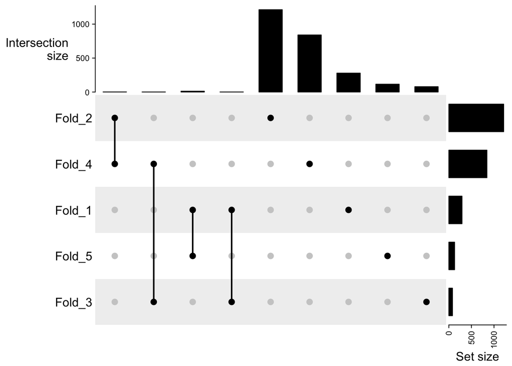

```r
IntLIM::PlotFoldOverlapUpSet(crossValResults$processed)
```

```r
# Find number of pairs overlapping in at least half of the folds.
result <- lapply(1:folds, function(j){return(rownames(crossValResults$processed[[j]]))})
result_flat <- unlist(result)
fold_count <- table(result_flat)
length(which(fold_count > folds / 2))

# Find number of pairs from original data that overlap the cross-validation data.
resultPairs <- paste(myres10$Analyte1, myres10$Analyte2, sep = "__")
foldCountResults<- fold_count[which(names(fold_count) %in% resultPairs)]
str(foldCountResults)
length(which(foldCountResults > folds / 2))
```

## Permutation

Finally, we run 2 permutations of the data. For large datasets and high numbers of permutations, you may wish to run your code on a supercomputer. For very large datasets, you may wish to create several batch jobs on a supercomputer, each of which calls **PermuteIntLIM()** with num.permutations = 1, and then concatenate the results after all jobs have completed. If you do this, it is recommended to change the seed for each call.

```r
perm.res <- IntLIM::PermuteIntLIM(data = inputDatafilt, stype = "DIAG", outcome = 2,
                      independent.var.type = 1, pvalcutoff = 0.10, interactionCoeffPercentile = 0.5,
                   rsquaredCutoff = 0.2,
                   num.permutations = 2,
                   covar = c("AGE", "RACE.ETHNICITY"))
```

```
## Running the analysis on discrete data with group sizes 47 61
```

```
## 10 % complete
```

```
## 20 % complete
```

```
## 30 % complete
```

```
## 40 % complete
```

```
## 50 % complete
```

```
## 60 % complete
```

```
## 70 % complete
```

```
## 80 % complete
```

```
## 90 % complete
```

```
## 7508 pairs found given cutoffs
```

```
## Running the analysis on discrete data with group sizes 47 61
```

```
## 10 % complete
```

```
## 20 % complete
```

```
## 30 % complete
```

```
## 40 % complete
```

```
## 50 % complete
```

```
## 60 % complete
```

```
## 70 % complete
```

```
## 80 % complete
```

```
## 90 % complete
```

```
## 10404 pairs found given cutoffs
```

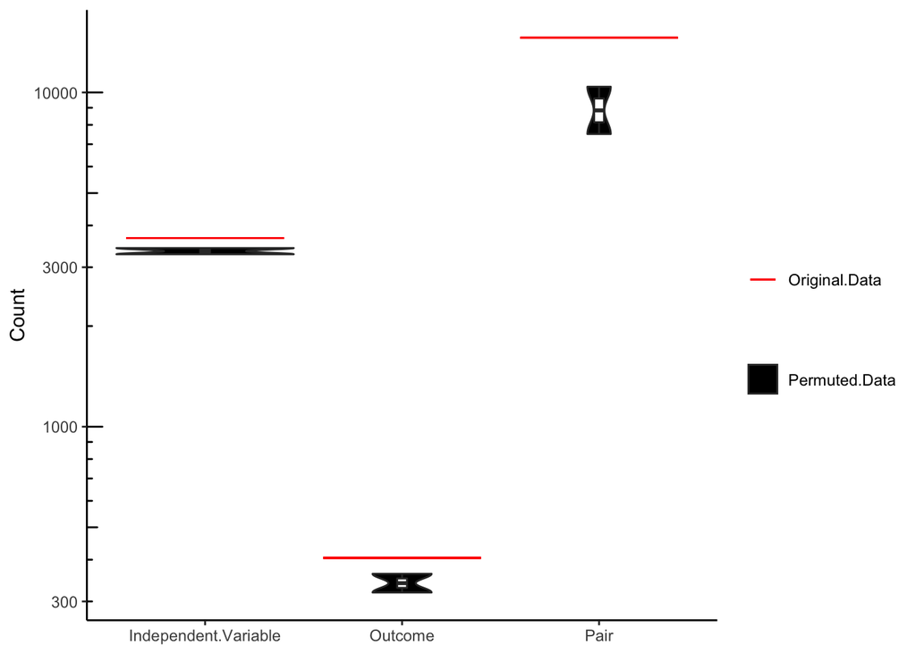

```r
summaryCount <- IntLIM::PermutationCountSummary(permResults = perm.res, inputResults = myres10,
                              plot = TRUE)
```

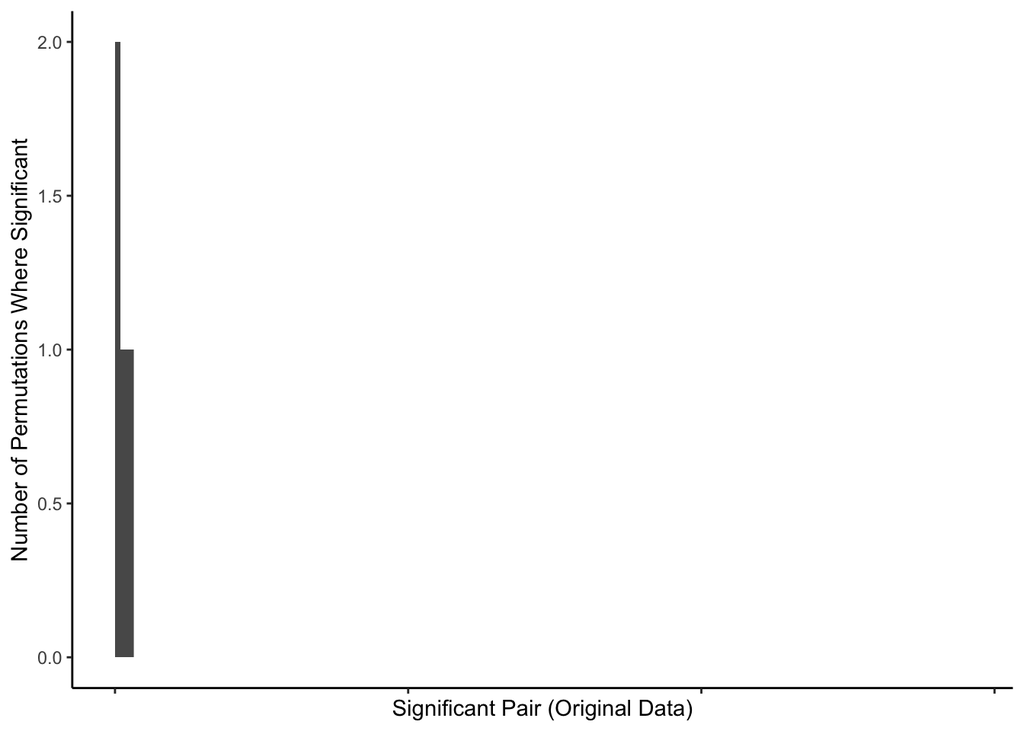

```r
print(summaryCount)

# Compute the number of times each pair significant in the original data was
# also significant in the permuted data.
summaryPairs <- IntLIM::PermutationPairSummary(permResults = perm.res, inputResults = myres10,
                              plot = TRUE)
```

```r
str(summaryPairs)
```

```r
# Further analyses reported in paper for comparison with original data
print(summaryPairs[which(summaryPairs$Pair == "ASNS__V__glutamine"),])
```

```
##                    Pair Perm.Count
## 9546 ASNS__V__glutamine          0
```

```r
print(summaryPairs[which(summaryPairs$Pair == "SLC7A1__V__glutamine"),])
```

```
##                      Pair Perm.Count
## 9524 SLC7A1__V__glutamine          0
```

```r
print(summaryPairs[which(summaryPairs$Pair == "GPT2__V__X2.hydroxyglutarate"),])
```

```
##                             Pair Perm.Count
## 195 GPT2__V__X2.hydroxyglutarate          0
```

```r
# Compare to pairs that share pathways.
pathwayPairs <- paste(myres10[which(sharesPathway == TRUE), "Analyte1"],
                        myres10[which(sharesPathway == TRUE), "Analyte2"], sep = "__V__")
length(which(summaryPairs[which(summaryPairs$Pair %in% pathwayPairs), "Perm.Count"] == 0))
```

```
## [1] 1352
```

```r
# Compare to pairs that share reactions.
rxnPairs <- paste(myres10[which(sharesRxn == TRUE), "Analyte1"],
                        myres10[which(sharesRxn == TRUE), "Analyte2"], sep = "__V__")
length(which(summaryPairs[which(summaryPairs$Pair %in% rxnPairs), "Perm.Count"] == 0))
```

```
## [1] 11
```

### Reference

1. Terunuma A, Putluri N, Mishra1 P, Mathé EA, Dorsey TH, Yi M, Wallace TA, Issaq HJ, Zhou M, Killian JK, Stevenson HS, Karoly ED, Chan K, Samanta S, Prieto D, Hsu TY.T., Kurley SJ, Putluri V, Sonavane R, Edelman DC, Wulff J, Starks AM, Yang Y, Kittles RA, Yfantis HG, Lee DH, Ioffe OB, Schiff R, Stephens RM, Meltzer PS, Veenstra TD, Westbrook TF, Sreekumar A, and Stefan Ambs S. MYC-driven 2-hydroxyglutarate associates with poor prognosis in breast cancer. J Clin Invest. 2014 Jan 2;124(1):398-412.
2. Siddiqui JK, Baskin E, Liu M, Cantemir-Stone CZ, Zhang B, Bonneville R, McElroy JP, Coombes KR, Mathé EA. IntLIM: integration using linear models of metabolomics and gene expression data. BMC bioinformatics. 2018 Dec;19(1):81.